# Covid Example

Dr. Clifton Baldwin

January 29, 2021

```r
library(tidyverse)
library(lubridate)
```

I downloaded a (small) dataset from the New England Journal of Medicine Lirong Zou, Feng Ruan,Mingxing Huang et.al. SARS-CoV-2 Viral Load in Upper Respiratory Specimens of Infected March 19, 2020 N Engl J Med 2020; 382:1177-1179 DOI: 10.1056/NEJMc2001737 https://www.nejm.org/doi/full/10.1056/NEJMc2001737

# Read and clean the data

Linux Command Line

- pdftotext -layout nejmc2001737_appendix.pdf # Convert pdf to text
- sed -E ‘s/,/;/g’ nejmc2001737_appendix.txt > nejmc2001737.csv # Change commas to semicolons
- sed -i ‘s/./&,/67;s/./&,/48;s/./&,/35;s/./&,/23;s/./&,/10’ nejmc2001737.csv # Add comma-delimiters
- sed -ni 1,21p nejmc2001737_appendix.csv # save only the first 21 lines

```r
covid <- read_csv('nejmc2001737.csv') # Read csv file
covid <- covid %>% janitor::clean_names() # Clean column names

# If there is an asterisk, the patient was severe
covid <- covid %>%
  mutate(severe = str_detect(covid$patient_id, "\\*"),
         fever = str_detect(tolower(covid$clinical_symptoms), "fever"),
         cough = str_detect(tolower(covid$clinical_symptoms), "cough"))

#Convert date_of_symptom to Date (because why not)
covid$date_of_symptom <- parse_date_time(covid$date_of_symptom, orders = c("dby"))
```

```
 1 failed to parse.
```

```r
covid %>% glimpse()
```

```
Rows: 18
Columns: 9
$ cases             <chr> "Imported", "Imported", "Imported", "Impo…
$ patient_id        <chr> "B", "C", "E*", "F", "I*", "K", "N", "O",…
$ gender            <chr> "M", "M", "M", "M", "M", "F", "F", "F", "…
$ age               <dbl> 44, 56, 36, 69, 78, 66, 50, 28, 76, 70, 6…
$ date_of_symptom   <dttm> 2020-01-24, 2020-01-19, 2020-01-17, 2020…
$ clinical_symptoms <chr> "Low fever; diarrhoea", "Fever; nausea; p…
$ severe            <lgl> FALSE, FALSE, TRUE, FALSE, TRUE, FALSE, F…
$ fever             <lgl> TRUE, TRUE, TRUE, TRUE, FALSE, FALSE, TRU…
$ cough             <lgl> FALSE, FALSE, TRUE, FALSE, TRUE, TRUE, FA…
```

What sympotoms were recorded?

```r
covid$clinical_symptoms
```

```
 [1] "Low fever; diarrhoea"
 [2] "Fever; nausea; palpation"
 [3] "Fever; weakness; myalgia; cough; haemoptysis"
 [4] "Fever; shortness of breath"
 [5] "Weakness; cough; nasal discharge; myalgia"
 [6] "Cough"
 [7] "Fever; chest distress"
 [8] "Cough"
 [9] "Headache; weakness; dry cough"
[10] "Fever; poor appetite; shortness of breath"
[11] "Cough"
[12] "Fever; dry cough"
[13] "Low fever; cough"
[14] "Fever; dry cough; shortness of breath; haemoptysis"
[15] "Headache"
[16] "Fever"
[17] "Cough"
[18] "No symptom"
```

Ok, we want to predict someone will have a severe case of Covid-19 so that we know to administer monoclonal antibodies. How can we predict the severity of disease for a newly infected person? We can look at people that had Covid-19 and see how the new patient relates.

Please note that this dataset is VERY SMALL. I am using it for demonstration purposes only. If we wanted any hope of accurate predictions, we would need a much larger sample size.

We hear in the news about age being a factor. Let us look at the data.

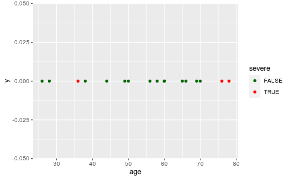

```r
covid %>%
  ggplot(aes(x=age, y = 0, colour = severe)) +
  geom_point() +
  scale_color_manual(values = c("TRUE" = "red", "FALSE" = "darkgreen"))
```

We see a group over the age of 75 with severe disease and one patient around 35 years old.

# Algorithm Pseudo-Code

1. Calculate the Euclidean Distance (or whatever distance measurement you want) between the test data and the training data.
2. For each test data observation, arrange the calculated Euclidean distances in non-decreasing order.
3. Take the first k distances from this sorted list as the neighbors.
4. Determine the dominant response within the neighbors as the prediction for the test data observation.

We choose K to represent how many neighbors to examine. In other words, how many other “nearby” people should we compare with the new patient? If we choose k = 3, then we want to know how severe are/were the three closest patients. This selection can be a weakness of the model because we may have to guess at how many neighbors are enough but not too many. If we choose too low a number for K, we may overfit the model (think someone will be too sick just because a few are very sick or not sick because a few are not sick). Choosing to large of a number for K may cause us to miss things. For example in our very small dataset, there are only 3 severe cases. If we choose k = 5 say, we would never predict someone might develop severe Covid-19, and then why bother “predicting”? Just say no one gets sick, which we know is false.

It looks like this K-Nearest Neighbors (KNN) model would work well with k = 3. And let us say two new people test positive for Covid-19. Based on age alone, we want to use a KNN model to predict if we should start monoclonal antibodies to treat for severe Covid-19.

Here is the same graph with the two new patients added.

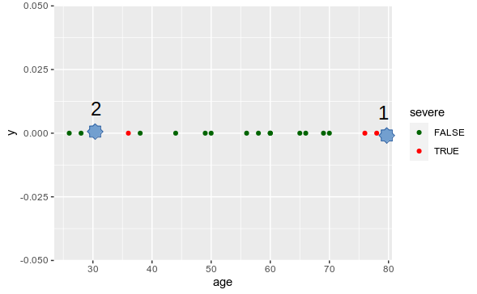

But that is just based on age! Maybe age and having a cough are indicative of severe disease.

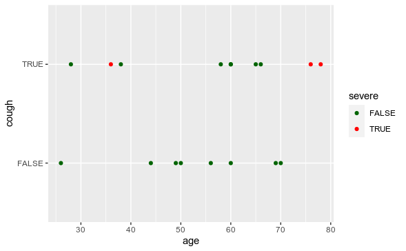

```r
covid %>%
  ggplot(aes(x=age, y = cough, colour = severe)) +
  geom_point() +
  scale_color_manual(values = c("TRUE" = "red", "FALSE" = "darkgreen"))
```

Again we calculate the distances between every set of points. What is the distance between True and False? Maybe we should label it 0 cough or 1 cough, which may or may not work well - but I am going with it.

Here is the graph again with our two latest patients.

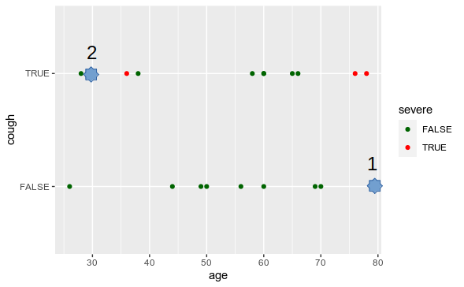

Now we see these 2 groups. When a new person gets sick, we can check their age and symptom of cough or not. (REMEMBER - this is just an example!!! We do not have enough data here to make any real predictions). However, in this example, KNN still predicts patient 2 will have a mild case. The prediction for patient 1 depends on the values for cough or not. I said 0 or 1, and then patient 1 would be predicted to be severe (closest to the 2 severe cases). But maybe medical doctors tell us a cough is worth 15 and no cough is 0. Then patient 1 is “closest” to the two mild cases at ages 69 and 70. As you can see, the way the model is configured can impact the results!

Although we cannot visualize well 3 dimensions (say age, cough and fever), we can check it with a KNN model. We just need to select an appropriate value for K (and numerical values for cough and fever). What about age, cough, fever, and sex? We can check that also, although it is difficult to “visualize” the 4 dimensions. Maybe we could do some trick using position, shapes, and colors, but what if we had 10 different factors (or dimensions)? No way we can visualize that in any meaningful manner. Nonetheless a KNN algorithm could make predictions using the 10 factors (or however many), given a large enough sample size.